# Creating Pretty Documents from R Markdown

The Architect Theme

Yixuan Qiu

2019-11-22

> Have you ever tried to find a lightweight yet nice theme for the R Markdown documents, just like this page?

## Themes for R Markdown

With the powerful `rmarkdown` package, we could easily create nice HTML document by adding some meta information in the header, for example

```yaml
---
title: Nineteen Years Later
author: Harry Potter
date: July 31, 2016
output:
  rmarkdown::html_document:
    theme: lumen
---
```

The `html_document` engine uses the [Bootswatch](https://bootswatch.com/) theme library to support different styles of the document. This is a quick and easy way to tune the appearance of your document, yet with the price of a large file size (> 700KB) since the whole [Bootstrap](https://getbootstrap.com/) library needs to be packed in.

For package vignettes, we can use the `html_vignette` engine to generate a more lightweight HTML file that is meant to minimize the package size, but the output HTML is less stylish than the `html_document` ones.

So can we do **BOTH**, a lightweight yet nice-looking theme for R Markdown?

## The prettydoc Engine

The answer is YES! (At least towards that direction)

The `prettydoc` package provides an alternative engine, `html_pretty`, to knit your R Markdown document into pretty HTML pages. Its usage is extremely easy: simply replace the `rmarkdown::html_document` or `rmarkdown::html_vignette` output engine by `prettydoc::html_pretty` in your R Markdown header, and use one of the built-in themes and syntax highlighters. For example

```yaml
---
title: Nineteen Years Later
author: Harry Potter
date: July 31, 2016
output:
  prettydoc::html_pretty:
    theme: cayman
    highlight: github
---
```

## Options and Themes

The options for the `html_pretty` engine are mostly compatible with the default `html_document` (see the [documentation](https://bookdown.org/yihui/rmarkdown/html-document.html)) with a few exceptions:

1. Currently the `theme` option can take the following values. More themes will be added in the future.
   - `cayman`: Modified from the [Cayman](https://github.com/jasonlong/cayman-theme) theme.
   - `tactile`: Modified from the [Tactile](https://github.com/jasonlong/tactile-theme) theme.
   - `architect`: Modified from the [Architect](https://github.com/jasonlong/architect-theme) theme.
   - `leonids`: Modified from the [Leonids](https://github.com/renyuanz/leonids) theme.
   - `hpstr`: Modified from the [HPSTR](https://github.com/mmistakes/hpstr-jekyll-theme) theme.
2. The `highlight` option takes value from `github` and `vignette`.
3. A new `math` parameter to choose between `mathjax` and `katex` for rendering math expressions. The `katex` option supports offline display when there is no internet connection.
4. Options `code_folding`, `code_download` and `toc_float` are not applicable.

## Offline Math Expressions

By default, `html_pretty` uses MathJax to render math expressions, for example inline math expressions $x^2 + y^2 = z^2$, and display formulas:

$$f(x)=\frac{1}{\sqrt{2\pi}\sigma}e^{-\frac{(x-\mu)^2}{2\sigma^2}}$$

However, using MathJax requires an internet connection. If you need to create documents that can show math expressions offline, simply add one line `math: katex` to the document metadata:

```yaml
---
title: Nineteen Years Later
author: Harry Potter
date: July 31, 2016
output:
  prettydoc::html_pretty:
    theme: cayman
    highlight: github
    math: katex
---
```

This option will enable [KaTeX](https://katex.org/) for rendering the math expressions, and all resource files will be included in for offline viewing. The offline document will be ~800k larger.

## Elements

We demonstrate some commonly used HTML elements here to show the apprearance of themes.

### Headers

#### Level 4

##### Level 5

### Tables

|  | Df | Sum Sq | Mean Sq | F value | Pr(>F) |  |
| --- | --- | --- | --- | --- | --- | --- |
| Block | 5 | 343.3 | 68.66 | 4.447 | 0.01594 | * |
| N | 1 | 189.3 | 189.28 | 12.259 | 0.00437 | ** |
| P | 1 | 8.4 | 8.40 | 0.544 | 0.47490 |  |
| K | 1 | 95.2 | 95.20 | 6.166 | 0.02880 | * |
| N:P | 1 | 21.3 | 21.28 | 1.378 | 0.26317 |  |
| N:K | 1 | 33.1 | 33.14 | 2.146 | 0.16865 |  |
| P:K | 1 | 0.5 | 0.48 | 0.031 | 0.86275 |  |
| Residuals | 12 | 185.3 | 15.44 |  |  |  |

### Lists

There are three kinds of lies:

1. Lies
2. Damned lies
3. Statistics
   - Frequentists
   - Bayesian
   - …

Supported highlighters in `prettydoc`:

- `github`: Style similar to Github
- `vignette`: Style used by `rmarkdown::html_vignette`

### Markups

**Bold**, *italic*, don’t say this.

### Code

Familiar `knitr` R code and plots:

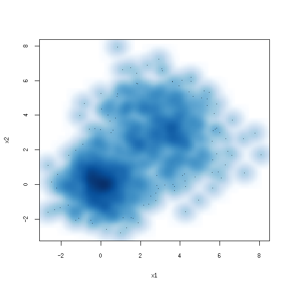

```r
set.seed(123)
n <- 1000
x1  <- matrix(rnorm(n), ncol = 2)
x2  <- matrix(rnorm(n, mean = 3, sd = 1.5), ncol = 2)
x   <- rbind(x1, x2)
smoothScatter(x, xlab = "x1", ylab = "x2")
```

```r
head(x)
```

```
##             [,1]        [,2]
## [1,] -0.56047565 -0.60189285
## [2,] -0.23017749 -0.99369859
## [3,]  1.55870831  1.02678506
## [4,]  0.07050839  0.75106130
## [5,]  0.12928774 -1.50916654
## [6,]  1.71506499 -0.09514745
```

Also try some other languages, for example C++.

```cpp
// [[Rcpp::depends(RcppEigen)]]
// [[Rcpp::depends(RcppNumerical)]]

#include <RcppNumerical.h>

using namespace Numer;

// f = 100 * (x2 - x1^2)^2 + (1 - x1)^2
// True minimum: x1 = x2 = 1
class Rosenbrock: public MFuncGrad
{
public:
    double f_grad(Constvec& x, Refvec grad)
    {
        double t1 = x[1] - x[0] * x[0];
        double t2 = 1 - x[0];
        grad[0] = -400 * x[0] * t1 - 2 * t2;
        grad[1] = 200 * t1;
        return 100 * t1 * t1 + t2 * t2;
    }
};

// [[Rcpp::export]]
Rcpp::List optim_test()
{
    Eigen::VectorXd x(2);
    x[0] = -1.2;
    x[1] = 1;
    double fopt;
    Rosenbrock f;
    int res = optim_lbfgs(f, x, fopt);
    return Rcpp::List::create(
        Rcpp::Named("xopt") = x,
        Rcpp::Named("fopt") = fopt,
        Rcpp::Named("status") = res
    );
}
```